# Introduction to Spark

## Basic initialization

`SparkSession` is used to connect to the Spark Cluster.

```python
from pyspark.sql import SparkSession
```

We will use Pandas to operate on the reduced data in the *driver program*.

```python
import pandas as pd
```

Numpy will be always useful.

```python
import numpy as np
```

Create a new session (or reuse an existing one).

```python
spark = SparkSession.builder.getOrCreate()
```

```python
spark
```

**SparkSession - in-memory**

**SparkContext**

[Spark UI](http://5a1a81290786:4040)

**Version**

`v3.0.0`

**Master**

`local[*]`

**AppName**

`pyspark-shell`

We can see that the session is established.

## Creating Spark Data Frames from Pandas

We can list the tables in our Spark Session, currently empty.

```python
print(spark.catalog.listTables())
```

```
[]
```

We can create a Pandas `DataFrame` with random values.

```python
pd_temp = pd.DataFrame(np.random.random(100))
```

We can see on the plot that it is really random:

```python
import matplotlib
import matplotlib.pyplot as plt
matplotlib.style.use('ggplot')
```

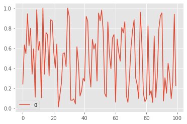

```python
pd_temp.plot()
```

Now we can convert it into Spark DataFrame:

```python
spark_temp = spark.createDataFrame(pd_temp)
```

`createOrReplaceTempView` creates (or replaces if that view name already exists) a lazily evaluated "view" that you can then use like a table in Spark SQL.

It does not persist to memory unless you cache (persist) the dataset that underpins the view.

```python
spark_temp.createOrReplaceTempView("temp")
```

The created view is `TEMPORARY` which means it is not persistent.

```python
print(spark.catalog.listTables())
```

```
[Table(name='temp', database=None, description=None, tableType='TEMPORARY', isTemporary=True)]
```

```python
spark_temp.show()
```

```
+-------------------+
|                  0|
+-------------------+
|0.24053189904301397|
| 0.6298120485924543|
| 0.5432051857533072|
| 0.9413193964123945|
|  0.621313485768691|
| 0.7965391389898137|
| 0.3376801571014185|
| 0.5913765063727854|
|0.10779224312830626|
| 0.9810447817111758|
| 0.5781110575164833|
|   0.66616787199484|
|0.10189118565012212|
| 0.9975755492302403|
| 0.3379046031010612|
| 0.7530465160800377|
| 0.7320329130763201|
|0.32153379222447576|
| 0.8813874686771791|
| 0.8722747034189491|
+-------------------+
only showing top 20 rows
```

We can now use transformations on this DataFrame. The transformations are translated (compiled) to RDD transformations.

```python
from pyspark.sql.functions import col, asc
```

```python
spark_temp.filter((col('0') > 0.9)).show()
```

```
+------------------+
|                 0|
+------------------+
|0.9413193964123945|
|0.9810447817111758|
|0.9975755492302403|
|0.9979915851467376|
|0.9162471762591021|
|0.9154509487934706|
|0.9486903946223691|
|0.9780988732052216|
|0.9577951379823926|
|0.9201382701668551|
|0.9505553244661742|
|0.9367855410864695|
+------------------+
```

## Creating Spark Data Frames from input files

```python
file_path = "airports.csv"

# Read in the airports data
airports = spark.read.csv(file_path,header=True)

# Show the data
print(airports.show())
```

```
+---------+--------------------+-------------+-----+-------+--------+----------+
|IATA_CODE|             AIRPORT|         CITY|STATE|COUNTRY|LATITUDE| LONGITUDE|
+---------+--------------------+-------------+-----+-------+--------+----------+
|      ABE|Lehigh Valley Int...|    Allentown|   PA|    USA|40.65236| -75.44040|
|      ABI|Abilene Regional ...|      Abilene|   TX|    USA|32.41132| -99.68190|
|      ABQ|Albuquerque Inter...|  Albuquerque|   NM|    USA|35.04022|-106.60919|
|      ABR|Aberdeen Regional...|     Aberdeen|   SD|    USA|45.44906| -98.42183|
|      ABY|Southwest Georgia...|       Albany|   GA|    USA|31.53552| -84.19447|
|      ACK|Nantucket Memoria...|    Nantucket|   MA|    USA|41.25305| -70.06018|
|      ACT|Waco Regional Air...|         Waco|   TX|    USA|31.61129| -97.23052|
|      ACV|      Arcata Airport|Arcata/Eureka|   CA|    USA|40.97812|-124.10862|
|      ACY|Atlantic City Int...|Atlantic City|   NJ|    USA|39.45758| -74.57717|
|      ADK|        Adak Airport|         Adak|   AK|    USA|51.87796|-176.64603|
|      ADQ|      Kodiak Airport|       Kodiak|   AK|    USA|57.74997|-152.49386|
|      AEX|Alexandria Intern...|   Alexandria|   LA|    USA|31.32737| -92.54856|
|      AGS|Augusta Regional ...|      Augusta|   GA|    USA|33.36996| -81.96450|
|      AKN| King Salmon Airport|  King Salmon|   AK|    USA|58.67680|-156.64922|
|      ALB|Albany Internatio...|       Albany|   NY|    USA|42.74812| -73.80298|
|      ALO|Waterloo Regional...|     Waterloo|   IA|    USA|42.55708| -92.40034|
|      AMA|Rick Husband Amar...|     Amarillo|   TX|    USA|35.21937|-101.70593|
|      ANC|Ted Stevens Ancho...|    Anchorage|   AK|    USA|61.17432|-149.99619|
|      APN|Alpena County Reg...|       Alpena|   MI|    USA|45.07807| -83.56029|
|      ASE|Aspen-Pitkin Coun...|        Aspen|   CO|    USA|39.22316|-106.86885|
+---------+--------------------+-------------+-----+-------+--------+----------+
only showing top 20 rows

None
```

It may be useful to convert them to Pandas for quick browsing.

**Warning!** This is not efficient for large datasets, as it requires performing actions on the dataset.

```python
airports.toPandas()
```

|  | IATA_CODE | AIRPORT | CITY | STATE | COUNTRY | LATITUDE | LONGITUDE |
| --- | --- | --- | --- | --- | --- | --- | --- |
| 0 | ABE | Lehigh Valley International Airport | Allentown | PA | USA | 40.65236 | -75.44040 |
| 1 | ABI | Abilene Regional Airport | Abilene | TX | USA | 32.41132 | -99.68190 |
| 2 | ABQ | Albuquerque International Sunport | Albuquerque | NM | USA | 35.04022 | -106.60919 |
| 3 | ABR | Aberdeen Regional Airport | Aberdeen | SD | USA | 45.44906 | -98.42183 |
| 4 | ABY | Southwest Georgia Regional Airport | Albany | GA | USA | 31.53552 | -84.19447 |
| ... | ... | ... | ... | ... | ... | ... | ... |
| 317 | WRG | Wrangell Airport | Wrangell | AK | USA | 56.48433 | -132.36982 |
| 318 | WYS | Westerly State Airport | West Yellowstone | MT | USA | 44.68840 | -111.11764 |
| 319 | XNA | Northwest Arkansas Regional Airport | Fayetteville/Springdale/Rogers | AR | USA | 36.28187 | -94.30681 |
| 320 | YAK | Yakutat Airport | Yakutat | AK | USA | 59.50336 | -139.66023 |
| 321 | YUM | Yuma International Airport | Yuma | AZ | USA | 32.65658 | -114.60597 |

322 rows × 7 columns

### Running SQL queries on dataframes

```python
airports.createOrReplaceTempView("airports")
```

```python
# Get the first 10 rows of flights
query = "FROM airports SELECT * LIMIT 10"

airports10 = spark.sql(query)

# Show the results
airports10.show()
```

```
+---------+--------------------+-------------+-----+-------+--------+----------+
|IATA_CODE|             AIRPORT|         CITY|STATE|COUNTRY|LATITUDE| LONGITUDE|
+---------+--------------------+-------------+-----+-------+--------+----------+
|      ABE|Lehigh Valley Int...|    Allentown|   PA|    USA|40.65236| -75.44040|
|      ABI|Abilene Regional ...|      Abilene|   TX|    USA|32.41132| -99.68190|
|      ABQ|Albuquerque Inter...|  Albuquerque|   NM|    USA|35.04022|-106.60919|
|      ABR|Aberdeen Regional...|     Aberdeen|   SD|    USA|45.44906| -98.42183|
|      ABY|Southwest Georgia...|       Albany|   GA|    USA|31.53552| -84.19447|
|      ACK|Nantucket Memoria...|    Nantucket|   MA|    USA|41.25305| -70.06018|
|      ACT|Waco Regional Air...|         Waco|   TX|    USA|31.61129| -97.23052|
|      ACV|      Arcata Airport|Arcata/Eureka|   CA|    USA|40.97812|-124.10862|
|      ACY|Atlantic City Int...|Atlantic City|   NJ|    USA|39.45758| -74.57717|
|      ADK|        Adak Airport|         Adak|   AK|    USA|51.87796|-176.64603|
+---------+--------------------+-------------+-----+-------+--------+----------+
```

### More complex examples

Read data from CSV file:

- `inferSchema` - to detect which columns are numbers (not strigs!) - useful e.g. for sorting.
- `header` - to read the firs line as column names

```python
countries = spark.read.csv("countries of the world.csv",inferSchema=True,header=True)
```

```python
countries.toPandas()
```

|  | Country | Region | Population | Area (sq. mi.) | Pop. Density (per sq. mi.) | Coastline (coast/area ratio) | Net migration | Infant mortality (per 1000 births) | GDP ($ per capita) | Literacy (%) | Phones (per 1000) | Arable (%) | Crops (%) | Other (%) | Climate | Birthrate | Deathrate | Agriculture | Industry | Service |
| --- | --- | --- | --- | --- | --- | --- | --- | --- | --- | --- | --- | --- | --- | --- | --- | --- | --- | --- | --- | --- |
| 0 | Afghanistan | ASIA (EX. NEAR EAST) | 31056997 | 647500 | 48,0 | 0,00 | 23,06 | 163,07 | 700.0 | 36,0 | 3,2 | 12,13 | 0,22 | 87,65 | 1 | 46,6 | 20,34 | 0,38 | 0,24 | 0,38 |
| 1 | Albania | EASTERN EUROPE | 3581655 | 28748 | 124,6 | 1,26 | -4,93 | 21,52 | 4500.0 | 86,5 | 71,2 | 21,09 | 4,42 | 74,49 | 3 | 15,11 | 5,22 | 0,232 | 0,188 | 0,579 |
| 2 | Algeria | NORTHERN AFRICA | 32930091 | 2381740 | 13,8 | 0,04 | -0,39 | 31 | 6000.0 | 70,0 | 78,1 | 3,22 | 0,25 | 96,53 | 1 | 17,14 | 4,61 | 0,101 | 0,6 | 0,298 |
| 3 | American Samoa | OCEANIA | 57794 | 199 | 290,4 | 58,29 | -20,71 | 9,27 | 8000.0 | 97,0 | 259,5 | 10 | 15 | 75 | 2 | 22,46 | 3,27 | None | None | None |
| 4 | Andorra | WESTERN EUROPE | 71201 | 468 | 152,1 | 0,00 | 6,6 | 4,05 | 19000.0 | 100,0 | 497,2 | 2,22 | 0 | 97,78 | 3 | 8,71 | 6,25 | None | None | None |
| ... | ... | ... | ... | ... | ... | ... | ... | ... | ... | ... | ... | ... | ... | ... | ... | ... | ... | ... | ... | ... |
| 222 | West Bank | NEAR EAST | 2460492 | 5860 | 419,9 | 0,00 | 2,98 | 19,62 | 800.0 | None | 145,2 | 16,9 | 18,97 | 64,13 | 3 | 31,67 | 3,92 | 0,09 | 0,28 | 0,63 |
| 223 | Western Sahara | NORTHERN AFRICA | 273008 | 266000 | 1,0 | 0,42 | None | None | NaN | None | None | 0,02 | 0 | 99,98 | 1 | None | None | None | None | 0,4 |
| 224 | Yemen | NEAR EAST | 21456188 | 527970 | 40,6 | 0,36 | 0 | 61,5 | 800.0 | 50,2 | 37,2 | 2,78 | 0,24 | 96,98 | 1 | 42,89 | 8,3 | 0,135 | 0,472 | 0,393 |
| 225 | Zambia | SUB-SAHARAN AFRICA | 11502010 | 752614 | 15,3 | 0,00 | 0 | 88,29 | 800.0 | 80,6 | 8,2 | 7,08 | 0,03 | 92,9 | 2 | 41 | 19,93 | 0,22 | 0,29 | 0,489 |
| 226 | Zimbabwe | SUB-SAHARAN AFRICA | 12236805 | 390580 | 31,3 | 0,00 | 0 | 67,69 | 1900.0 | 90,7 | 26,8 | 8,32 | 0,34 | 91,34 | 2 | 28,01 | 21,84 | 0,179 | 0,243 | 0,579 |

227 rows × 20 columns

We can inspect the schema of the DataFrame.

```python
countries.printSchema()
```

```
root
 |-- Country: string (nullable = true)
 |-- Region: string (nullable = true)
 |-- Population: integer (nullable = true)
 |-- Area (sq. mi.): integer (nullable = true)
 |-- Pop. Density (per sq. mi.): string (nullable = true)
 |-- Coastline (coast/area ratio): string (nullable = true)
 |-- Net migration: string (nullable = true)
 |-- Infant mortality (per 1000 births): string (nullable = true)
 |-- GDP ($ per capita): integer (nullable = true)
 |-- Literacy (%): string (nullable = true)
 |-- Phones (per 1000): string (nullable = true)
 |-- Arable (%): string (nullable = true)
 |-- Crops (%): string (nullable = true)
 |-- Other (%): string (nullable = true)
 |-- Climate: string (nullable = true)
 |-- Birthrate: string (nullable = true)
 |-- Deathrate: string (nullable = true)
 |-- Agriculture: string (nullable = true)
 |-- Industry: string (nullable = true)
 |-- Service: string (nullable = true)
```

### Examples of SQL Queries

```python
countries.createOrReplaceTempView("countries")
```

```python
spark.sql("SELECT * FROM countries WHERE Region LIKE '%OCEANIA%'").toPandas()
```

|  | Country | Region | Population | Area (sq. mi.) | Pop. Density (per sq. mi.) | Coastline (coast/area ratio) | Net migration | Infant mortality (per 1000 births) | GDP ($ per capita) | Literacy (%) | Phones (per 1000) | Arable (%) | Crops (%) | Other (%) | Climate | Birthrate | Deathrate | Agriculture | Industry | Service |
| --- | --- | --- | --- | --- | --- | --- | --- | --- | --- | --- | --- | --- | --- | --- | --- | --- | --- | --- | --- | --- |
| 0 | American Samoa | OCEANIA | 57794 | 199 | 290,4 | 58,29 | -20,71 | 9,27 | 8000 | 97,0 | 259,5 | 10 | 15 | 75 | 2 | 22,46 | 3,27 | None | None | None |
| 1 | Australia | OCEANIA | 20264082 | 7686850 | 2,6 | 0,34 | 3,98 | 4,69 | 29000 | 100,0 | 565,5 | 6,55 | 0,04 | 93,41 | 1 | 12,14 | 7,51 | 0,038 | 0,262 | 0,7 |
| 2 | Cook Islands | OCEANIA | 21388 | 240 | 89,1 | 50,00 | None | None | 5000 | 95,0 | 289,9 | 17,39 | 13,04 | 69,57 | 2 | 21 | None | 0,151 | 0,096 | 0,753 |
| 3 | Fiji | OCEANIA | 905949 | 18270 | 49,6 | 6,18 | -3,14 | 12,62 | 5800 | 93,7 | 112,6 | 10,95 | 4,65 | 84,4 | 2 | 22,55 | 5,65 | 0,089 | 0,135 | 0,776 |
| 4 | French Polynesia | OCEANIA | 274578 | 4167 | 65,9 | 60,60 | 2,94 | 8,44 | 17500 | 98,0 | 194,5 | 0,82 | 5,46 | 93,72 | 2 | 16,68 | 4,69 | 0,031 | 0,19 | 0,769 |
| 5 | Guam | OCEANIA | 171019 | 541 | 316,1 | 23,20 | 0 | 6,94 | 21000 | 99,0 | 492,0 | 9,09 | 16,36 | 74,55 | 2 | 18,79 | 4,48 | None | None | None |
| 6 | Kiribati | OCEANIA | 105432 | 811 | 130,0 | 140,94 | 0 | 48,52 | 800 | None | 42,7 | 2,74 | 50,68 | 46,58 | 2 | 30,65 | 8,26 | 0,089 | 0,242 | 0,668 |
| 7 | Marshall Islands | OCEANIA | 60422 | 11854 | 5,1 | 3,12 | -6,04 | 29,45 | 1600 | 93,7 | 91,2 | 16,67 | 38,89 | 44,44 | 2 | 33,05 | 4,78 | 0,317 | 0,149 | 0,534 |
| 8 | Micronesia, Fed. St. | OCEANIA | 108004 | 702 | 153,9 | 870,66 | -20,99 | 30,21 | 2000 | 89,0 | 114,8 | 5,71 | 45,71 | 48,58 | 2 | 24,68 | 4,75 | 0,289 | 0,152 | 0,559 |
| 9 | Nauru | OCEANIA | 13287 | 21 | 632,7 | 142,86 | 0 | 9,95 | 5000 | None | 143,0 | 0 | 0 | 100 | 2 | 24,76 | 6,7 | None | None | None |
| 10 | New Caledonia | OCEANIA | 219246 | 19060 | 11,5 | 11,83 | 0 | 7,72 | 15000 | 91,0 | 252,2 | 0,38 | 0,33 | 99,29 | 2 | 18,11 | 5,69 | 0,15 | 0,088 | 0,762 |
| 11 | New Zealand | OCEANIA | 4076140 | 268680 | 15,2 | 5,63 | 4,05 | 5,85 | 21600 | 99,0 | 441,7 | 5,6 | 6,99 | 87,41 | 3 | 13,76 | 7,53 | 0,043 | 0,273 | 0,684 |
| 12 | N. Mariana Islands | OCEANIA | 82459 | 477 | 172,9 | 310,69 | 9,61 | 7,11 | 12500 | 97,0 | 254,7 | 13,04 | 4,35 | 82,61 | 2 | 19,43 | 2,29 | None | None | None |
| 13 | Palau | OCEANIA | 20579 | 458 | 44,9 | 331,66 | 2,85 | 14,84 | 9000 | 92,0 | 325,6 | 8,7 | 4,35 | 86,95 | 2 | 18,03 | 6,8 | 0,062 | 0,12 | 0,818 |
| 14 | Papua New Guinea | OCEANIA | 5670544 | 462840 | 12,3 | 1,11 | 0 | 51,45 | 2200 | 64,6 | 10,9 | 0,46 | 1,44 | 98,1 | 2 | 29,36 | 7,25 | 0,353 | 0,381 | 0,266 |
| 15 | Samoa | OCEANIA | 176908 | 2944 | 60,1 | 13,69 | -11,7 | 27,71 | 5600 | 99,7 | 75,2 | 21,2 | 24,38 | 54,42 | 2 | 16,43 | 6,62 | 0,114 | 0,584 | 0,302 |
| 16 | Solomon Islands | OCEANIA | 552438 | 28450 | 19,4 | 18,67 | 0 | 21,29 | 1700 | None | 13,4 | 0,64 | 2 | 97,36 | 2 | 30,01 | 3,92 | 0,42 | 0,11 | 0,47 |
| 17 | Tonga | OCEANIA | 114689 | 748 | 153,3 | 56,02 | 0 | 12,62 | 2200 | 98,5 | 97,7 | 23,61 | 43,06 | 33,33 | 2 | 25,37 | 5,28 | 0,23 | 0,27 | 0,5 |
| 18 | Tuvalu | OCEANIA | 11810 | 26 | 454,2 | 92,31 | 0 | 20,03 | 1100 | None | 59,3 | 0 | 0 | 100 | 2 | 22,18 | 7,11 | 0,166 | 0,272 | 0,562 |
| 19 | Vanuatu | OCEANIA | 208869 | 12200 | 17,1 | 20,72 | 0 | 55,16 | 2900 | 53,0 | 32,6 | 2,46 | 7,38 | 90,16 | 2 | 22,72 | 7,82 | 0,26 | 0,12 | 0,62 |
| 20 | Wallis and Futuna | OCEANIA | 16025 | 274 | 58,5 | 47,08 | None | None | 3700 | 50,0 | 118,6 | 5 | 25 | 70 | 2 | None | None | None | None | None |

### Queries using PySpark DSL

DSL = Domain Specific Language - API similar to natural or other language, implemented as library in another language.

List all the countries with the population > 38 million

```python
countries.filter((col("Population") > 38000000)).orderBy("Population").toPandas()
```

|  | Country | Region | Population | Area (sq. mi.) | Pop. Density (per sq. mi.) | Coastline (coast/area ratio) | Net migration | Infant mortality (per 1000 births) | GDP ($ per capita) | Literacy (%) | Phones (per 1000) | Arable (%) | Crops (%) | Other (%) | Climate | Birthrate | Deathrate | Agriculture | Industry | Service |
| --- | --- | --- | --- | --- | --- | --- | --- | --- | --- | --- | --- | --- | --- | --- | --- | --- | --- | --- | --- | --- |
| 0 | Poland | EASTERN EUROPE | 38536869 | 312685 | 123,3 | 0,16 | -0,49 | 8,51 | 11100 | 99,8 | 306,3 | 45,91 | 1,12 | 52,97 | 3 | 9,85 | 9,89 | 0,05 | 0,311 | 0,64 |
| 1 | Argentina | LATIN AMER. & CARIB | 39921833 | 2766890 | 14,4 | 0,18 | 0,61 | 15,18 | 11200 | 97,1 | 220,4 | 12,31 | 0,48 | 87,21 | 3 | 16,73 | 7,55 | 0,095 | 0,358 | 0,547 |
| 2 | Spain | WESTERN EUROPE | 40397842 | 504782 | 80,0 | 0,98 | 0,99 | 4,42 | 22000 | 97,9 | 453,5 | 26,07 | 9,87 | 64,06 | 3 | 10,06 | 9,72 | 0,04 | 0,295 | 0,665 |
| 3 | Sudan | SUB-SAHARAN AFRICA | 41236378 | 2505810 | 16,5 | 0,03 | -0,02 | 62,5 | 1900 | 61,1 | 16,3 | 6,83 | 0,18 | 92,99 | 2 | 34,53 | 8,97 | 0,387 | 0,203 | 0,41 |
| 4 | Colombia | LATIN AMER. & CARIB | 43593035 | 1138910 | 38,3 | 0,28 | -0,31 | 20,97 | 6300 | 92,5 | 176,2 | 2,42 | 1,67 | 95,91 | 2 | 20,48 | 5,58 | 0,125 | 0,342 | 0,533 |
| 5 | South Africa | SUB-SAHARAN AFRICA | 44187637 | 1219912 | 36,2 | 0,23 | -0,29 | 61,81 | 10700 | 86,4 | 107,0 | 12,08 | 0,79 | 87,13 | 1 | 18,2 | 22 | 0,025 | 0,303 | 0,671 |
| 6 | Ukraine | C.W. OF IND. STATES | 46710816 | 603700 | 77,4 | 0,46 | -0,39 | 20,34 | 5400 | 99,7 | 259,9 | 56,21 | 1,61 | 42,18 | 3 | 8,82 | 14,39 | 0,187 | 0,452 | 0,361 |
| 7 | Burma | ASIA (EX. NEAR EAST) | 47382633 | 678500 | 69,8 | 0,28 | -1,8 | 67,24 | 1800 | 85,3 | 10,1 | 15,19 | 0,97 | 83,84 | 2 | 17,91 | 9,83 | 0,564 | 0,082 | 0,353 |
| 8 | Korea, South | ASIA (EX. NEAR EAST) | 48846823 | 98480 | 496,0 | 2,45 | 0 | 7,05 | 17800 | 97,9 | 486,1 | 17,18 | 1,95 | 80,87 | 3 | 10 | 5,85 | 0,033 | 0,403 | 0,563 |
| 9 | Italy | WESTERN EUROPE | 58133509 | 301230 | 193,0 | 2,52 | 2,07 | 5,94 | 26700 | 98,6 | 430,9 | 27,79 | 9,53 | 62,68 | None | 8,72 | 10,4 | 0,021 | 0,291 | 0,688 |
| 10 | United Kingdom | WESTERN EUROPE | 60609153 | 244820 | 247,6 | 5,08 | 2,19 | 5,16 | 27700 | 99,0 | 543,5 | 23,46 | 0,21 | 76,33 | 3 | 10,71 | 10,13 | 0,005 | 0,237 | 0,758 |
| 11 | France | WESTERN EUROPE | 60876136 | 547030 | 111,3 | 0,63 | 0,66 | 4,26 | 27600 | 99,0 | 586,4 | 33,53 | 2,07 | 64,4 | 4 | 11,99 | 9,14 | 0,022 | 0,214 | 0,764 |
| 12 | Congo, Dem. Rep. | SUB-SAHARAN AFRICA | 62660551 | 2345410 | 26,7 | 0,00 | 0 | 94,69 | 700 | 65,5 | 0,2 | 2,96 | 0,52 | 96,52 | 2 | 43,69 | 13,27 | 0,55 | 0,11 | 0,34 |
| 13 | Thailand | ASIA (EX. NEAR EAST) | 64631595 | 514000 | 125,7 | 0,63 | 0 | 20,48 | 7400 | 92,6 | 108,9 | 29,36 | 6,46 | 64,18 | 2 | 13,87 | 7,04 | 0,099 | 0,441 | 0,46 |
| 14 | Iran | ASIA (EX. NEAR EAST) | 68688433 | 1648000 | 41,7 | 0,15 | -0,84 | 41,58 | 7000 | 79,4 | 276,4 | 8,72 | 1,39 | 89,89 | 1 | 17 | 5,55 | 0,116 | 0,424 | 0,46 |
| 15 | Turkey | NEAR EAST | 70413958 | 780580 | 90,2 | 0,92 | 0 | 41,04 | 6700 | 86,5 | 269,5 | 30,93 | 3,31 | 65,76 | 3 | 16,62 | 5,97 | 0,117 | 0,298 | 0,585 |
| 16 | Ethiopia | SUB-SAHARAN AFRICA | 74777981 | 1127127 | 66,3 | 0,00 | 0 | 95,32 | 700 | 42,7 | 8,2 | 10,71 | 0,75 | 88,54 | 2 | 37,98 | 14,86 | 0,475 | 0,099 | 0,426 |
| 17 | Egypt | NORTHERN AFRICA | 78887007 | 1001450 | 78,8 | 0,24 | -0,22 | 32,59 | 4000 | 57,7 | 131,8 | 2,87 | 0,48 | 96,65 | 1 | 22,94 | 5,23 | 0,149 | 0,357 | 0,493 |
| 18 | Germany | WESTERN EUROPE | 82422299 | 357021 | 230,9 | 0,67 | 2,18 | 4,16 | 27600 | 99,0 | 667,9 | 33,85 | 0,59 | 65,56 | 3 | 8,25 | 10,62 | 0,009 | 0,296 | 0,695 |
| 19 | Vietnam | ASIA (EX. NEAR EAST) | 84402966 | 329560 | 256,1 | 1,05 | -0,45 | 25,95 | 2500 | 90,3 | 187,7 | 19,97 | 5,95 | 74,08 | 2 | 16,86 | 6,22 | 0,209 | 0,41 | 0,381 |
| 20 | Philippines | ASIA (EX. NEAR EAST) | 89468677 | 300000 | 298,2 | 12,10 | -1,5 | 23,51 | 4600 | 92,6 | 38,4 | 18,95 | 16,77 | 64,28 | 2 | 24,89 | 5,41 | 0,144 | 0,326 | 0,53 |
| 21 | Mexico | LATIN AMER. & CARIB | 107449525 | 1972550 | 54,5 | 0,47 | -4,87 | 20,91 | 9000 | 92,2 | 181,6 | 12,99 | 1,31 | 85,7 | 1,5 | 20,69 | 4,74 | 0,038 | 0,259 | 0,702 |
| 22 | Japan | ASIA (EX. NEAR EAST) | 127463611 | 377835 | 337,4 | 7,87 | 0 | 3,26 | 28200 | 99,0 | 461,2 | 12,19 | 0,96 | 86,85 | 3 | 9,37 | 9,16 | 0,017 | 0,258 | 0,725 |
| 23 | Nigeria | SUB-SAHARAN AFRICA | 131859731 | 923768 | 142,7 | 0,09 | 0,26 | 98,8 | 900 | 68,0 | 9,3 | 31,29 | 2,96 | 65,75 | 1,5 | 40,43 | 16,94 | 0,269 | 0,487 | 0,244 |
| 24 | Russia | C.W. OF IND. STATES | 142893540 | 17075200 | 8,4 | 0,22 | 1,02 | 15,39 | 8900 | 99,6 | 280,6 | 7,33 | 0,11 | 92,56 | None | 9,95 | 14,65 | 0,054 | 0,371 | 0,575 |
| 25 | Bangladesh | ASIA (EX. NEAR EAST) | 147365352 | 144000 | 1023,4 | 0,40 | -0,71 | 62,6 | 1900 | 43,1 | 7,3 | 62,11 | 3,07 | 34,82 | 2 | 29,8 | 8,27 | 0,199 | 0,198 | 0,603 |
| 26 | Pakistan | ASIA (EX. NEAR EAST) | 165803560 | 803940 | 206,2 | 0,13 | -2,77 | 72,44 | 2100 | 45,7 | 31,8 | 27,87 | 0,87 | 71,26 | 1 | 29,74 | 8,23 | 0,216 | 0,251 | 0,533 |
| 27 | Brazil | LATIN AMER. & CARIB | 188078227 | 8511965 | 22,1 | 0,09 | -0,03 | 29,61 | 7600 | 86,4 | 225,3 | 6,96 | 0,9 | 92,15 | 2 | 16,56 | 6,17 | 0,084 | 0,4 | 0,516 |
| 28 | Indonesia | ASIA (EX. NEAR EAST) | 245452739 | 1919440 | 127,9 | 2,85 | 0 | 35,6 | 3200 | 87,9 | 52,0 | 11,32 | 7,23 | 81,45 | 2 | 20,34 | 6,25 | 0,134 | 0,458 | 0,408 |
| 29 | United States | NORTHERN AMERICA | 298444215 | 9631420 | 31,0 | 0,21 | 3,41 | 6,5 | 37800 | 97,0 | 898,0 | 19,13 | 0,22 | 80,65 | 3 | 14,14 | 8,26 | 0,01 | 0,204 | 0,787 |
| 30 | India | ASIA (EX. NEAR EAST) | 1095351995 | 3287590 | 333,2 | 0,21 | -0,07 | 56,29 | 2900 | 59,5 | 45,4 | 54,4 | 2,74 | 42,86 | 2,5 | 22,01 | 8,18 | 0,186 | 0,276 | 0,538 |
| 31 | China | ASIA (EX. NEAR EAST) | 1313973713 | 9596960 | 136,9 | 0,15 | -0,4 | 24,18 | 5000 | 90,9 | 266,7 | 15,4 | 1,25 | 83,35 | 1,5 | 13,25 | 6,97 | 0,125 | 0,473 | 0,403 |

Select all the countries from Europe

```python
countries.select("Country", "Population").where(col("Region").like("%EUROPE%")).show()
```

```
+--------------------+----------+
|             Country|Population|
+--------------------+----------+
|            Albania |   3581655|
|            Andorra |     71201|
|            Austria |   8192880|
|            Belgium |  10379067|
|Bosnia & Herzegov...|   4498976|
|           Bulgaria |   7385367|
|            Croatia |   4494749|
|     Czech Republic |  10235455|
|            Denmark |   5450661|
|      Faroe Islands |     47246|
|            Finland |   5231372|
|             France |  60876136|
|            Germany |  82422299|
|          Gibraltar |     27928|
|             Greece |  10688058|
|           Guernsey |     65409|
|            Hungary |   9981334|
|            Iceland |    299388|
|            Ireland |   4062235|
|        Isle of Man |     75441|
+--------------------+----------+
only showing top 20 rows
```

Conditions in `where` clause can contain logical expressions.

```python
countries.select("Country", "Population")\
.where((col("Region").like("%EUROPE%")) & (col("Population")> 10000000)).show()
```

```
+---------------+----------+
|        Country|Population|
+---------------+----------+
|       Belgium |  10379067|
|Czech Republic |  10235455|
|        France |  60876136|
|       Germany |  82422299|
|        Greece |  10688058|
|         Italy |  58133509|
|   Netherlands |  16491461|
|        Poland |  38536869|
|      Portugal |  10605870|
|       Romania |  22303552|
|         Spain |  40397842|
|United Kingdom |  60609153|
+---------------+----------+
```

### Aggregation

We can run aggregations with predefined functions (faster!):

```python
from pyspark.sql.functions import sum
```

```python
pd_countries = countries.select("Region", "Population").groupBy("Region").agg(sum("Population")).toPandas()
```

```python
pd_countries
```

|  | Region | sum(Population) |
| --- | --- | --- |
| 0 | BALTICS | 7184974 |
| 1 | C.W. OF IND. STATES | 280081548 |
| 2 | ASIA (EX. NEAR EAST) | 3687982236 |
| 3 | WESTERN EUROPE | 396339998 |
| 4 | NORTHERN AMERICA | 331672307 |
| 5 | NEAR EAST | 195068377 |
| 6 | EASTERN EUROPE | 119914717 |
| 7 | OCEANIA | 33131662 |
| 8 | SUB-SAHARAN AFRICA | 749437000 |
| 9 | NORTHERN AFRICA | 161407133 |
| 10 | LATIN AMER. & CARIB | 561824599 |

We can make the column name look better, by using `alias`:

```python
pd_countries = countries.select("Region", "Population").groupBy("Region").agg(sum("Population").alias('Total')).toPandas()
```

```python
pd_countries
```

|  | Region | Total |
| --- | --- | --- |
| 0 | BALTICS | 7184974 |
| 1 | C.W. OF IND. STATES | 280081548 |
| 2 | ASIA (EX. NEAR EAST) | 3687982236 |
| 3 | WESTERN EUROPE | 396339998 |
| 4 | NORTHERN AMERICA | 331672307 |
| 5 | NEAR EAST | 195068377 |
| 6 | EASTERN EUROPE | 119914717 |
| 7 | OCEANIA | 33131662 |
| 8 | SUB-SAHARAN AFRICA | 749437000 |
| 9 | NORTHERN AFRICA | 161407133 |
| 10 | LATIN AMER. & CARIB | 561824599 |

### Plot examples

Pandas DataFrames are useful for plotting using MatPlotLib:

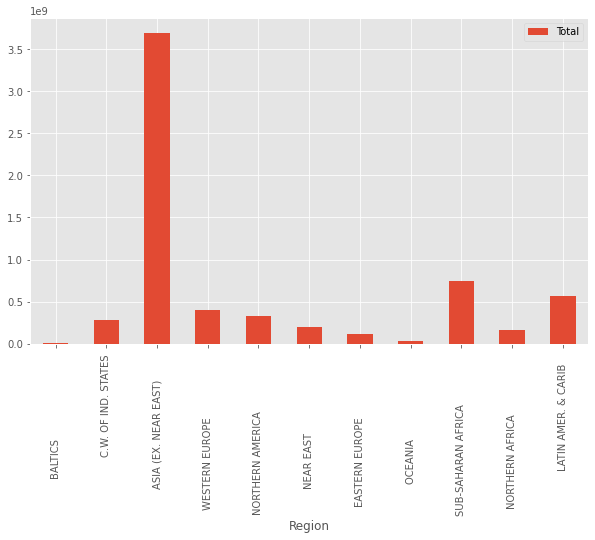

```python
pd_countries.plot(x='Region', y='Total',kind='bar', figsize=(10, 6))
```

## User defined functions for data manipulation

Our `countries` DataFrame has some problems:

- missing values
- some numbers use comma instead of point as floating point separator (e.g. Literacy = 99,4)

We can clean the data using User Defined Functions (UDF)

```python
from pyspark.sql.types import FloatType
from pyspark.sql.functions import udf
```

Define a Python function which coverts numbers with commas to `float`

```python
def to_float (s) :
   return float(s.replace(',','.'))
```

Test that it works:

```python
to_float('0,99')
```

```
0.99
```

Now define a Spark UDF:

```python
float_udf = udf(to_float , FloatType())
```

Test it on a Data Frame

```python
countries.withColumn("Literacy", float_udf("Literacy (%)"))
```

```
DataFrame[Country: string, Region: string, Population: int, Area (sq. mi.): int, Pop. Density (per sq. mi.): string, Coastline (coast/area ratio): string, Net migration: string, Infant mortality (per 1000 births): string, GDP ($ per capita): int, Literacy (%): string, Phones (per 1000): string, Arab…
```

OK, we can see that the `Literacy` is now `float`

```python
countries.show(50)
```

```
+--------------------+--------------------+----------+--------------+--------------------------+----------------------------+-------------+----------------------------------+------------------+------------+-----------------+----------+---------+---------+-------+---------+---------+-----------+-----…
|             Country|              Region|Population|Area (sq. mi.)|Pop. Density (per sq. mi.)|Coastline (coast/area ratio)|Net migration|Infant mortality (per 1000 births)|GDP ($ per capita)|Literacy (%)|Phones (per 1000)|Arable (%)|Crops (%)|Other (%)|Climate|Birthrate|Deathrate|Agriculture|Indus…
+--------------------+--------------------+----------+--------------+--------------------------+----------------------------+-------------+----------------------------------+------------------+------------+-----------------+----------+---------+---------+-------+---------+---------+-----------+-----…
|        Afghanistan |ASIA (EX. NEAR EA...|  31056997|        647500|                      48,0|                        0,00|        23,06|                            163,07|               700|        36,0|              3,2|     12,13|     0,22|    87,65|      1|     46,6|    20,34|       0,38|    0…
|            Albania |EASTERN EUROPE   ...|   3581655|         28748|                     124,6|                        1,26|        -4,93|                             21,52|              4500|        86,5|             71,2|     21,09|     4,42|    74,49|      3|    15,11|     5,22|      0,232|   0,…
|            Algeria |NORTHERN AFRICA  ...|  32930091|       2381740|                      13,8|                        0,04|        -0,39|                                31|              6000|        70,0|             78,1|      3,22|     0,25|    96,53|      1|    17,14|     4,61|      0,101|     …
|     American Samoa |OCEANIA          ...|     57794|           199|                     290,4|                       58,29|       -20,71|                              9,27|              8000|        97,0|            259,5|        10|       15|       75|      2|    22,46|     3,27|       null|    n…
|            Andorra |WESTERN EUROPE   ...|     71201|           468|                     152,1|                        0,00|          6,6|                              4,05|             19000|       100,0|            497,2|      2,22|        0|    97,78|      3|     8,71|     6,25|       null|    n…
|             Angola |SUB-SAHARAN AFRIC...|  12127071|       1246700|                       9,7|                        0,13|            0|                            191,19|              1900|        42,0|              7,8|      2,41|     0,24|    97,35|   null|    45,11|     24,2|      0,096|   0,…
|           Anguilla |LATIN AMER. & CAR...|     13477|           102|                     132,1|                       59,80|        10,76|                             21,03|              8600|        95,0|            460,0|         0|        0|      100|      2|    14,17|     5,34|       0,04|    0…
|  Antigua & Barbuda |LATIN AMER. & CAR...|     69108|           443|                     156,0|                       34,54|        -6,15|                             19,46|             11000|        89,0|            549,9|     18,18|     4,55|    77,27|      2|    16,93|     5,37|      0,038|    0…
|          Argentina |LATIN AMER. & CAR...|  39921833|       2766890|                      14,4|                        0,18|         0,61|                             15,18|             11200|        97,1|            220,4|     12,31|     0,48|    87,21|      3|    16,73|     7,55|      0,095|   0,…
|            Armenia |C.W. OF IND. STATES |   2976372|         29800|                      99,9|                        0,00|        -6,47|                             23,28|              3500|        98,6|            195,7|     17,55|      2,3|    80,15|      4|    12,07|     8,23|      0,239|   0,…
|              Aruba |LATIN AMER. & CAR...|     71891|           193|                     372,5|                       35,49|            0|                              5,89|             28000|        97,0|            516,1|     10,53|        0|    89,47|      2|    11,03|     6,68|      0,004|   0,…
|          Australia |OCEANIA          ...|  20264082|       7686850|                       2,6|                        0,34|         3,98|                              4,69|             29000|       100,0|            565,5|      6,55|     0,04|    93,41|      1|    12,14|     7,51|      0,038|   0,…
|            Austria |WESTERN EUROPE   ...|   8192880|         83870|                      97,7|                        0,00|            2|                              4,66|             30000|        98,0|            452,2|     16,91|     0,86|    82,23|      3|     8,74|     9,76|      0,018|   0,…
```

[output cut: 39 more lines]

```python
countries.where((col("Literacy") < 50) & (col("GDP ($ per capita)") > 700)).show()
```

```
---------------------------------------------------------------------------
AnalysisException                         Traceback (most recent call last)
<ipython-input-40-691580c0a6c2> in <module>
----> 1 countries.where((col("Literacy") < 50) & (col("GDP ($ per capita)") > 700)).show()

/usr/local/spark/python/pyspark/sql/dataframe.py in filter(self, condition)
   1459             jdf = self._jdf.filter(condition)
   1460         elif isinstance(condition, Column):
-> 1461             jdf = self._jdf.filter(condition._jc)
   1462         else:
   1463             raise TypeError("condition should be string or Column")

/usr/local/spark/python/lib/py4j-0.10.9-src.zip/py4j/java_gateway.py in __call__(self, *args)
   1302
   1303         answer = self.gateway_client.send_command(command)
-> 1304         return_value = get_return_value(
   1305             answer, self.gateway_client, self.target_id, self.name)
   1306

/usr/local/spark/python/pyspark/sql/utils.py in deco(*a, **kw)
    135                 # Hide where the exception came from that shows a non-Pythonic
    136                 # JVM exception message.
--> 137                 raise_from(converted)
    138             else:
    139                 raise

/usr/local/spark/python/pyspark/sql/utils.py in raise_from(e)

AnalysisException: cannot resolve '`Literacy`' given input columns: [Agriculture, Arable (%), Area (sq. mi.), Birthrate, Climate, Coastline (coast/area ratio), Country, Crops (%), Deathrate, GDP ($ per capita), Industry, Infant mortality (per 1000 births), Literacy (%), Net migration, Other (%), Pho…
'Filter (('Literacy < 50) AND (GDP ($ per capita)#184 > 700))
+- Relation[Country#176,Region#177,Population#178,Area (sq. mi.)#179,Pop. Density (per sq. mi.)#180,Coastline (coast/area ratio)#181,Net migration#182,Infant mortality (per 1000 births)#183,GDP ($ per capita)#184,Literacy (%)#185,Phones (per 1000)#186,Arable (%)#187,Crops (%)#188,Other (%)#189,Clima…
```

Oops, what does it mean???

Before we can use the table, we need to remove empty rows. Otherwise our UDF will fail.

```python
full_countries = countries.select('Country', 'Population', 'Literacy (%)', 'GDP ($ per capita)').na.drop()
```

We can now apply the new UDF to the Data Frame:

```python
full_countries = full_countries.withColumn("Literacy", float_udf("Literacy (%)"))
```

```python
full_countries.show(50)
```

```
+--------------------+----------+------------+------------------+--------+
|             Country|Population|Literacy (%)|GDP ($ per capita)|Literacy|
+--------------------+----------+------------+------------------+--------+
|        Afghanistan |  31056997|        36,0|               700|    36.0|
|            Albania |   3581655|        86,5|              4500|    86.5|
|            Algeria |  32930091|        70,0|              6000|    70.0|
|     American Samoa |     57794|        97,0|              8000|    97.0|
|            Andorra |     71201|       100,0|             19000|   100.0|
|             Angola |  12127071|        42,0|              1900|    42.0|
|           Anguilla |     13477|        95,0|              8600|    95.0|
|  Antigua & Barbuda |     69108|        89,0|             11000|    89.0|
|          Argentina |  39921833|        97,1|             11200|    97.1|
|            Armenia |   2976372|        98,6|              3500|    98.6|
|              Aruba |     71891|        97,0|             28000|    97.0|
|          Australia |  20264082|       100,0|             29000|   100.0|
|            Austria |   8192880|        98,0|             30000|    98.0|
|         Azerbaijan |   7961619|        97,0|              3400|    97.0|
|       Bahamas, The |    303770|        95,6|             16700|    95.6|
|            Bahrain |    698585|        89,1|             16900|    89.1|
|         Bangladesh | 147365352|        43,1|              1900|    43.1|
|           Barbados |    279912|        97,4|             15700|    97.4|
|            Belarus |  10293011|        99,6|              6100|    99.6|
|            Belgium |  10379067|        98,0|             29100|    98.0|
|             Belize |    287730|        94,1|              4900|    94.1|
|              Benin |   7862944|        40,9|              1100|    40.9|
|            Bermuda |     65773|        98,0|             36000|    98.0|
|             Bhutan |   2279723|        42,2|              1300|    42.2|
|            Bolivia |   8989046|        87,2|              2400|    87.2|
|           Botswana |   1639833|        79,8|              9000|    79.8|
|             Brazil | 188078227|        86,4|              7600|    86.4|
| British Virgin Is. |     23098|        97,8|             16000|    97.8|
|             Brunei |    379444|        93,9|             18600|    93.9|
|           Bulgaria |   7385367|        98,6|              7600|    98.6|
|       Burkina Faso |  13902972|        26,6|              1100|    26.6|
|              Burma |  47382633|        85,3|              1800|    85.3|
|            Burundi |   8090068|        51,6|               600|    51.6|
|           Cambodia |  13881427|        69,4|              1900|    69.4|
|           Cameroon |  17340702|        79,0|              1800|    79.0|
|             Canada |  33098932|        97,0|             29800|    97.0|
|         Cape Verde |    420979|        76,6|              1400|    76.6|
|     Cayman Islands |     45436|        98,0|             35000|    98.0|
|Central African R...|   4303356|        51,0|              1100|    51.0|
|               Chad |   9944201|        47,5|              1200|    47.5|
|              Chile |  16134219|        96,2|              9900|    96.2|
|              China |1313973713|        90,9|              5000|    90.9|
|           Colombia |  43593035|        92,5|              6300|    92.5|
|            Comoros |    690948|        56,5|               700|    56.5|
|   Congo, Dem. Rep. |  62660551|        65,5|               700|    65.5|
|Congo, Repub. of ...|   3702314|        83,8|               700|    83.8|
|       Cook Islands |     21388|        95,0|              5000|    95.0|
|         Costa Rica |   4075261|        96,0|              9100|    96.0|
|      Cote d'Ivoire |  17654843|        50,9|              1400|    50.9|
|            Croatia |   4494749|        98,5|             10600|    98.5|
+--------------------+----------+------------+------------------+--------+
only showing top 50 rows
```

```python
full_countries.where((col("Literacy") < 50) & (col("GDP ($ per capita)") > 700)).show()
```

```
+--------------+----------+------------+------------------+--------+
|       Country|Population|Literacy (%)|GDP ($ per capita)|Literacy|
+--------------+----------+------------+------------------+--------+
|       Angola |  12127071|        42,0|              1900|    42.0|
|   Bangladesh | 147365352|        43,1|              1900|    43.1|
|        Benin |   7862944|        40,9|              1100|    40.9|
|       Bhutan |   2279723|        42,2|              1300|    42.2|
| Burkina Faso |  13902972|        26,6|              1100|    26.6|
|         Chad |   9944201|        47,5|              1200|    47.5|
|  Gambia, The |   1641564|        40,1|              1700|    40.1|
|       Guinea |   9690222|        35,9|              2100|    35.9|
|Guinea-Bissau |   1442029|        42,4|               800|    42.4|
|         Iraq |  26783383|        40,4|              1500|    40.4|
|         Mali |  11716829|        46,4|               900|    46.4|
|   Mauritania |   3177388|        41,7|              1800|    41.7|
|   Mozambique |  19686505|        47,8|              1200|    47.8|
|        Nepal |  28287147|        45,2|              1400|    45.2|
|        Niger |  12525094|        17,6|               800|    17.6|
|     Pakistan | 165803560|        45,7|              2100|    45.7|
|      Senegal |  11987121|        40,2|              1600|    40.2|
+--------------+----------+------------+------------------+--------+
```

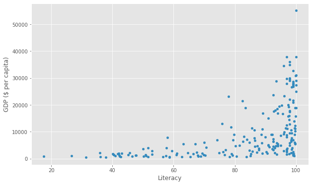

```python
full_countries.toPandas().plot(x="Literacy",y="GDP ($ per capita)",kind="scatter",figsize=(10, 6))
```

# Useful information

- https://spark.apache.org/docs/latest/quick-start.html
- https://spark.apache.org/docs/latest/sql-programming-guide.html
- https://pandas.pydata.org/pandas-docs/stable/visualization.html